# Lab 2, CP 4: Análise completa

```r
library(tidyverse)
library(scales)
library(here)
library(knitr)
library("lubridate")
theme_set(theme_bw())
```

## Dataset

Os dados utilizados durante a análise foram coletados por meio do registro de logs dos eventos ocorridos durante interações de usuários no site do Wikipédia no periodo entre 01 a 08 de março no ano 2016. Estes dados foram disponibilizados pela organização sem fins lucrativos que gerencia o site da Wikipédia, a Wikimedia Foundation.

A coleta dos dados teve o objetivo de investigar as seguintes perguntas:

1. Qual é a taxa de cliques nos diferendes dias? Como isso varia nos dois grupos?
2. Considerando os resultados das buscas, o resultado de qual posição os usuário tendem a clicar? Como isso muda durantes os diferentes dias?
3. Qual é a taxa de buscas com zero resultados? Como isso varia nos dois grupos?
4. Considerando o tempo aproximado de duração da sessão de cada usuário como o registro do primeiro e último evento, os usuários com maior número de cliques tendem a ter um tempo de sessão maior? Como isso varia nos dois grupos?

```r
buscas = read_csv(here::here("data/search_data.csv"))
```

1. Verificar se existe o caso de usuário buscou e não clicou

Existe sessões somente com buscas tipo sessão que buscou duas vezes e não clicou

Existe sessões que a pessoa visitou páginas mais position_result é NA

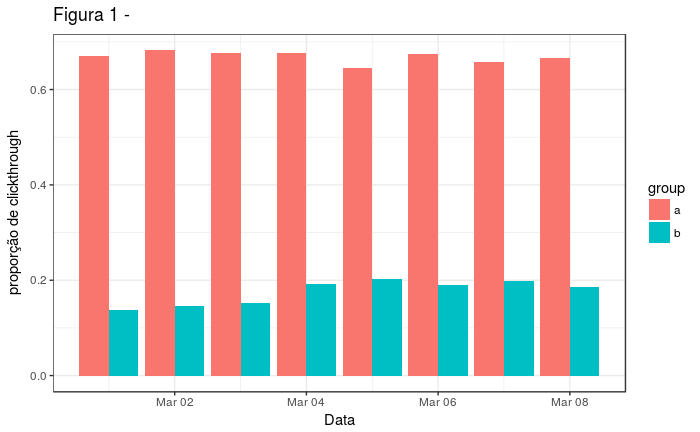

```r
   buscas %>%
        group_by(data = as.Date(session_start_date), group) %>%
        summarise(clickthrough = sum(num_clicks > 0)/n()) %>%
        ggplot(aes(x = as.Date(data), y = clickthrough, fill = group)) +
        geom_col(position = "dodge") +
        scale_x_date('Data', date_labels = "%b %d") +
        labs(y= "proporção de clickthrough", title="Figura 1 -")
```

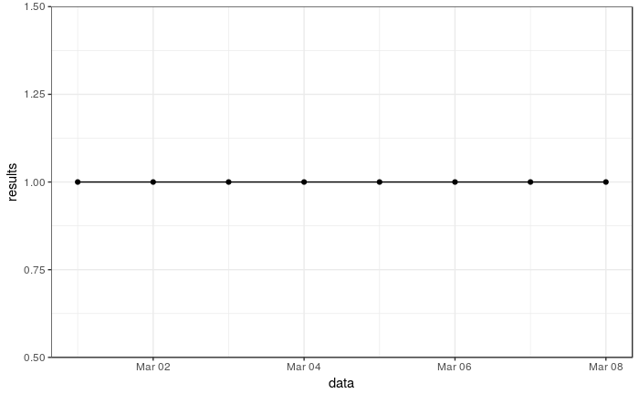

```r
    buscas %>%
        group_by(data = as.Date(session_start_date)) %>%
        summarise(results = median(position_clicked, na.rm = TRUE), results_max = max(position_clicked, na.rm = TRUE)) %>%
        ggplot(aes(x = data, y = results)) +
        geom_line() + geom_point()
```

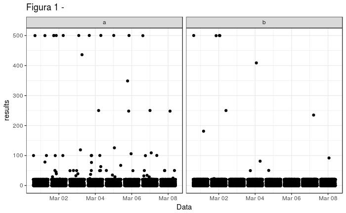

```r
    buscas %>%
        ggplot(aes(x = as.Date(session_start_date), y = results)) +
        geom_jitter()+
        scale_x_date('Data', date_labels = "%b %d") +
        labs(y= "results", title="Figura 1 -") +
        facet_grid(. ~ group)
```

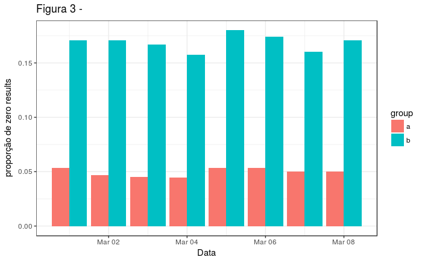

```r
     buscas %>%
        filter(search_index > 0) %>%
        group_by(data = as.Date(session_start_date), group) %>%
        summarise(zero_results = sum(na.omit(results) == 0)/n()) %>%
        ggplot(aes(x = as.Date(data), y = zero_results, fill = group)) +
        geom_col(position = "dodge") +
        scale_x_date('Data', date_labels = "%b %d") +
        labs(y= "proporção de zero results", title="Figura 3 -")
```

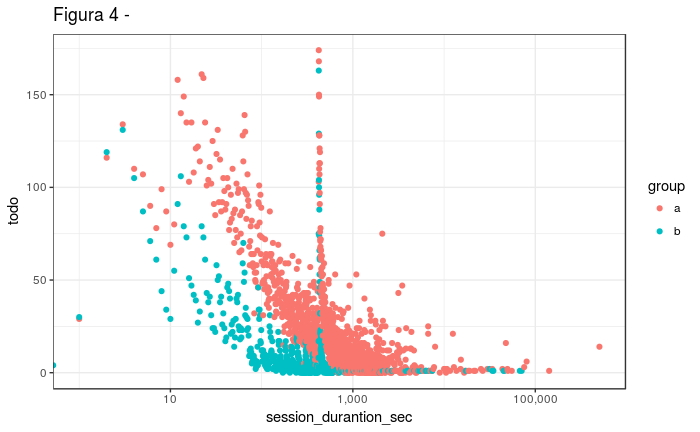

```r
    buscas %>%
        group_by(session_durantion_sec, group) %>%
        summarise(click_number = sum(na.omit(num_clicks))) %>%
        ggplot(aes(x = session_durantion_sec , y = click_number, color = group)) +
        geom_point() + scale_x_log10(labels = comma) +
        labs(y= "todo", title="Figura 4 -")
```